# 9. Testing for Complete Spatial Randomness

# Testing for CSR

Distance-based measure using events locations: however there are $n(n-1)/2$ inter-event distances to check for the $n$ *nearest neighbour distances* so is computationally intensive. To deal with computationally this a tesselation or triangulation is used usually.

*Delauney/Voronoi tesslation*: the Dirichlet tile associated with point $Z(s_i)$ is the region of space that is closer to $Z(s_i)$ than to any other point in $Z(s)$.

*Delauney triangulation*: 1) Construct the Dirchlet/Voronoi tesselation, 2) Two points are Delauney neighbours if their Dirchlet/Voronoi tiles share a common boundary. This results in a tesselation of disjoint triangles (the union of the triangles is the convex hull).

# Testing for CSR

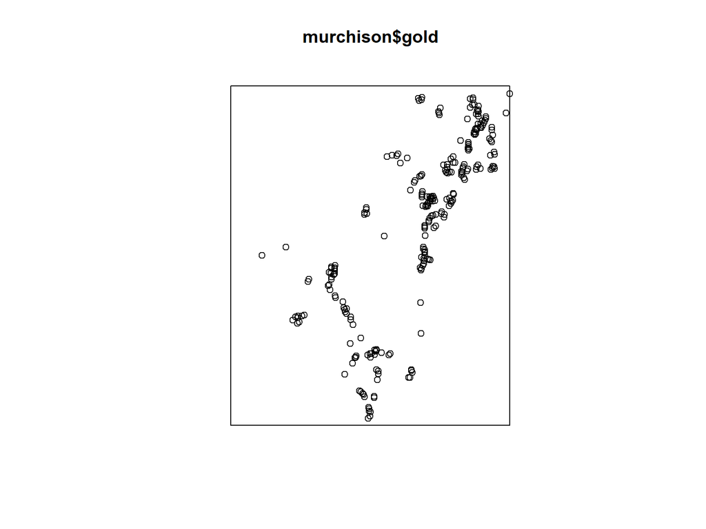

```r
plot(murchison$gold)
```

```r
nm <- nndist.ppp(murchison$gold)
#nm
summary(nm)
```

```
##    Min. 1st Qu.  Median    Mean 3rd Qu.    Max.
##   899.3  1810.4  2174.8  3515.4  2892.0 36118.0
```

# Testing for CSR

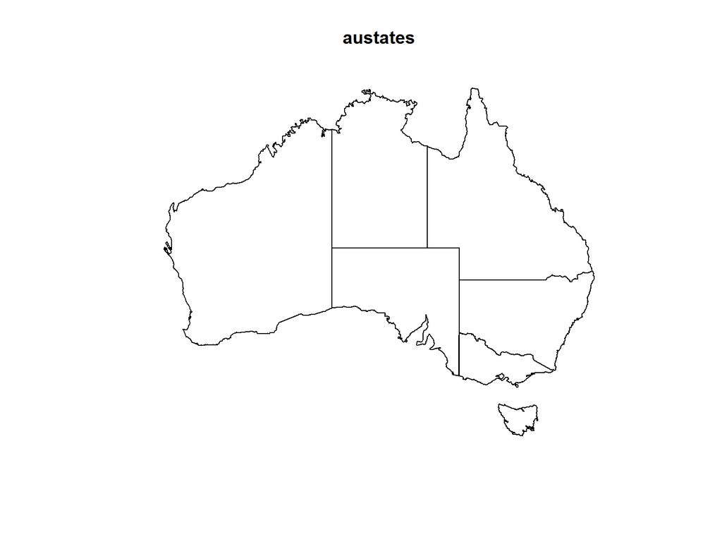

```r
plot(austates)
```

```r
a <- austates
```

# Testing for CSR

```r
ld <- as.tess(austates)
ld
```

```
## Tessellation
## Tiles are irregular polygons
## 7 tiles (irregular windows)
## window: polygonal boundary
## enclosing rectangle: [113.19392, 153.6692] x [-43.59316, -10.93156] units
```

# Testing for CSR

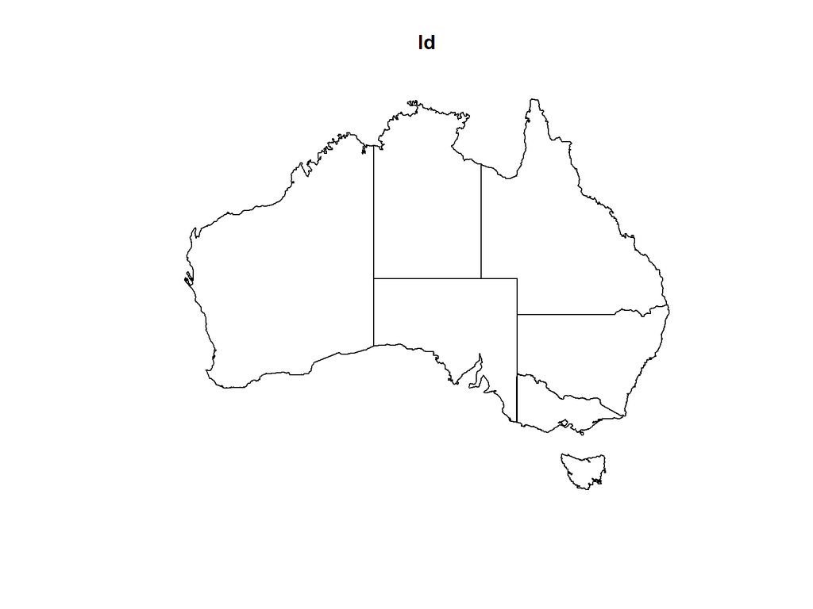

```r
plot(ld)
```

# Testing for CSR

```r
summary(austates)
```

```
##        Length Class  Mode
## type   1      -none- character
## window 5      owin   list
## tiles  7      -none- list
## n      1      -none- numeric
```

# Testing for CSR

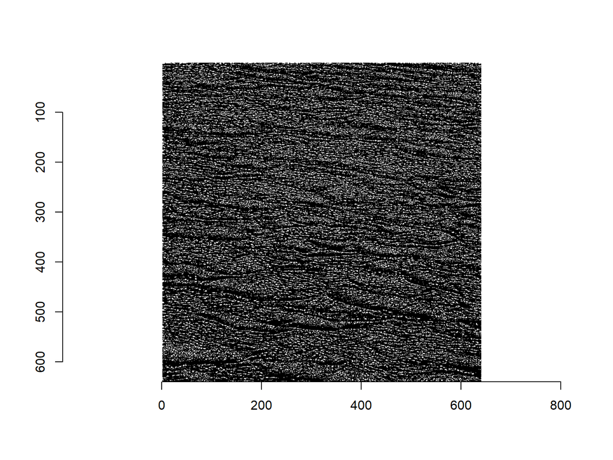

```r
x <- load.image("scale1to10.jpg")
#Reads in the image as a matrix (uses jpeg package)
t <- threshold(x, 0.5)
#returns a binary image (matrix) (uses EBImage package)
plot(t)
```

# Testing for CSR

```r
m <- matrix(t, ncol = ncol(x), nrow = nrow(x))  #blank matrix
ss <- ncol(x)
m <- m[,ncol(m):1]
z <- NULL
for (i in 1:ncol(t)) {
   for (j in 1:nrow(t)) {
        if (m[i,j] == 1){
            z <- rbind(z,c(i,j))
        } } }
ww <- owin(c(0,ncol(t)), c(0,nrow(t)))
d <- as.ppp(z,ww)
dsub <-d[owin(c(0,100), c(0,100))]
```

# Testing for CSR

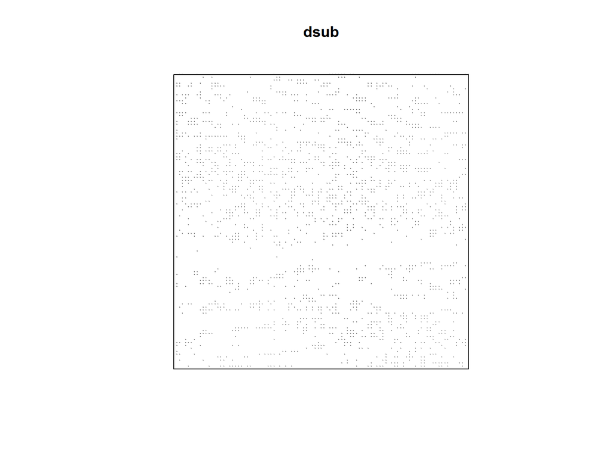

```r
plot(dsub, pch = 20, cex = 0.1 )
```

# Testing for CSR

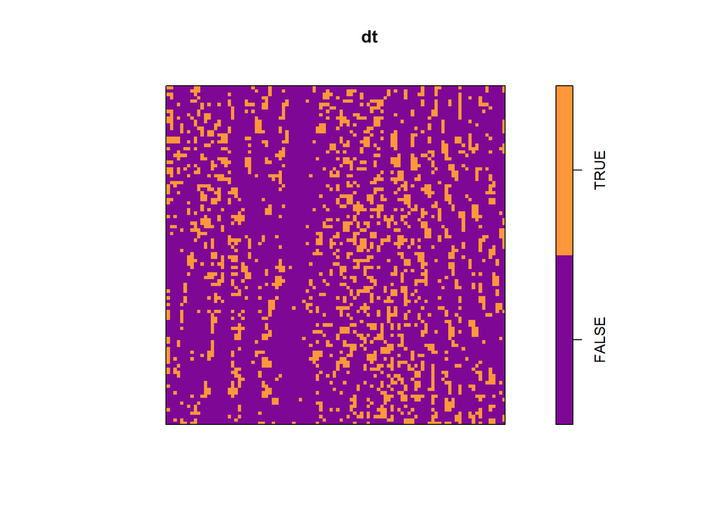

```r
dt <- tess(dsub, image = m[1:100,1:100],
           window = owin(c(0,100), c(0,100) ))
plot(dt)
```

# Testing for CSR

```r
tiles(dt)
```

```
## List of spatial objects
##
## FALSE:
## window: binary image mask
## 100 x 100 pixel array (ny, nx)
## enclosing rectangle: [0.5, 100.5] x [0.5, 100.5] units
##
## TRUE:
## window: binary image mask
## 100 x 100 pixel array (ny, nx)
## enclosing rectangle: [0.5, 100.5] x [0.5, 100.5] units
```

```r
dtd <- dirichlet(dsub)
dtd
```

```
## Tessellation
## Tiles are windows of general type
## 1894 tiles (irregular windows)
## window: rectangle = [0, 100] x [0, 100] units
```

# Testing for CSR

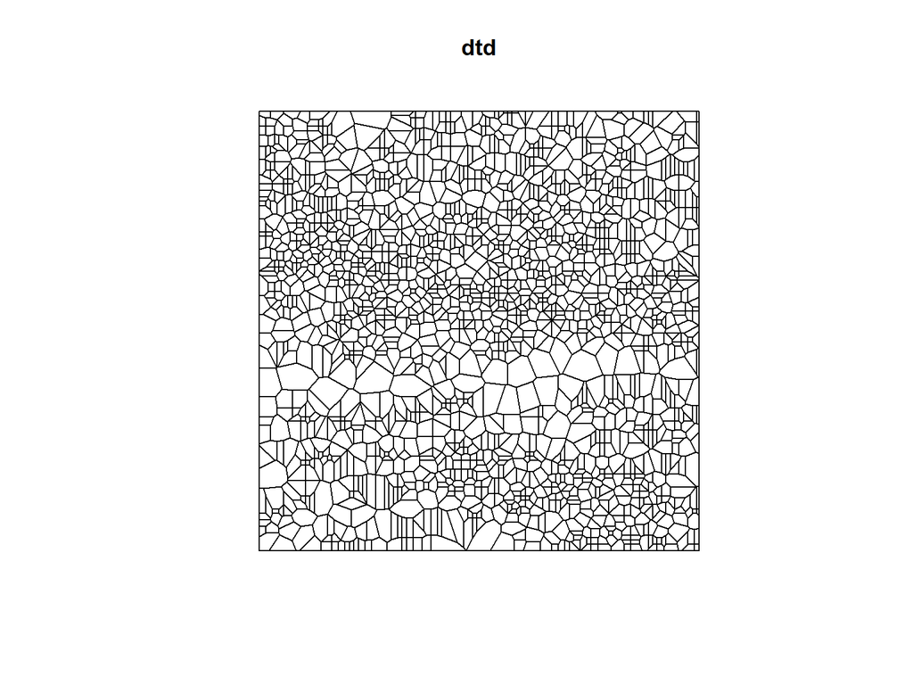

```r
plot(dtd)
```

# $F$-function: the empty-space function

$F(r) = P[\rho(a,x) \le r]$: the probability of observing at least one point closer than $r$ to the arbitrary point $a$ (not necessarily a point of the pattern). If the estimate is smaller than CSR ($F(r) = 1- e^{-\pi \lambda r^2}$) then the points are clustered, if larger than CSR then the points are regular.

$1-F (r)$ is the probability that a randomly placed disk with radius $r$ does not contain a point.

# $F$-function: the empty-space function

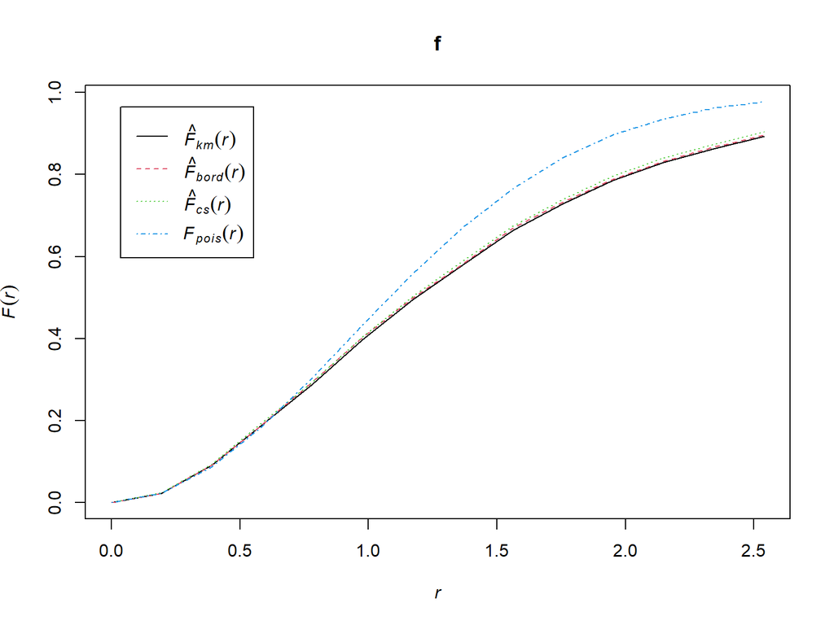

```r
ff <- Fest(dsub, correction = "none")
f <- Fest(dsub)
plot(f)
```

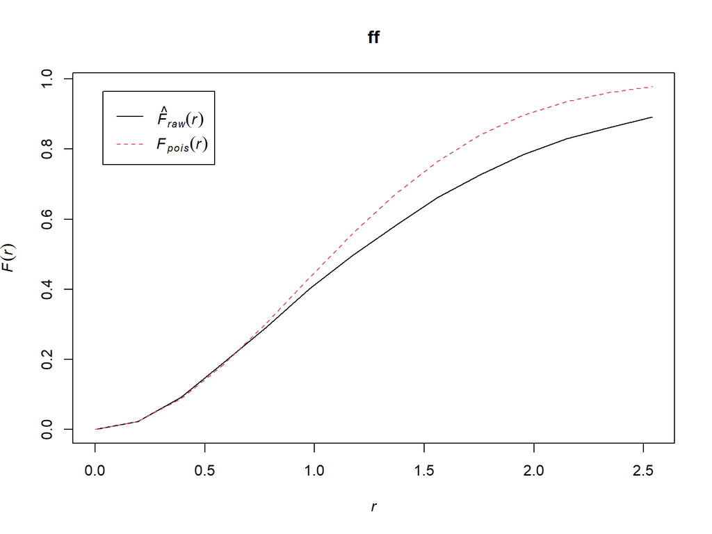

```r
plot(ff)
```

# $F$-function: the empty-space function

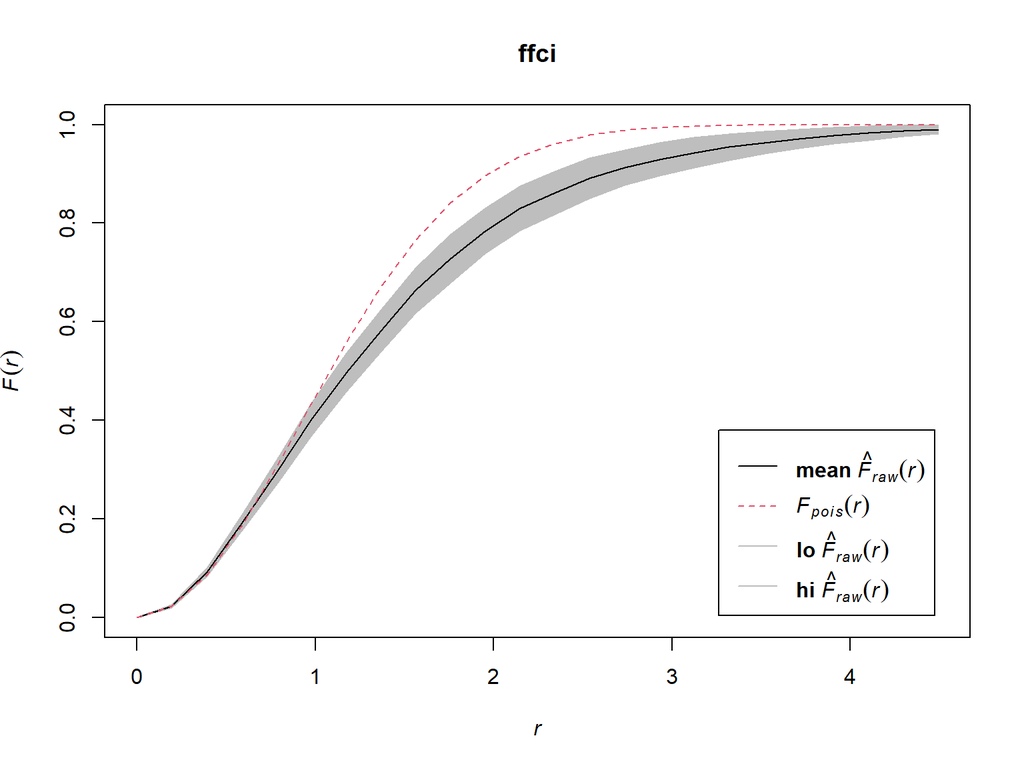

```r
ffci <- varblock(dsub, fun = Fest, correction = "none")
plot(ffci)
```

```r
#ffciloh <- lohboot(dsub, fun = Fest, correction = "none")
```

# $F$-function: the empty-space function

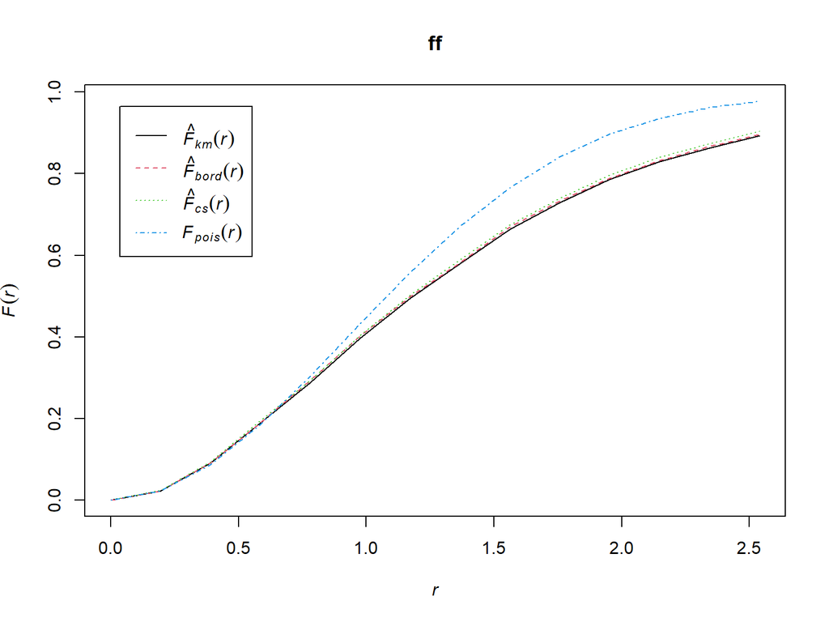

```r
ff <- Fest(dsub)
plot(ff)
```

# $F$-function: the empty-space function

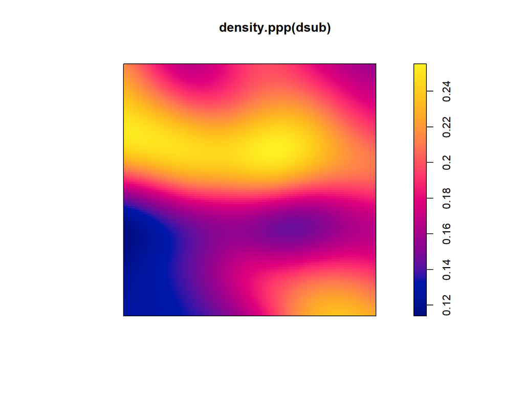

```r
plot(density.ppp(dsub))
```

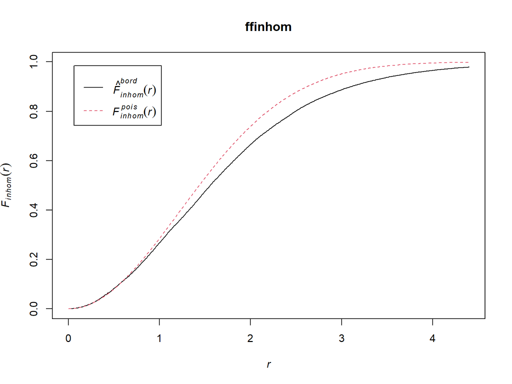

```r
ffinhom <- Finhom(dsub)
plot(ffinhom)
```

# $F$-function: the empty-space function

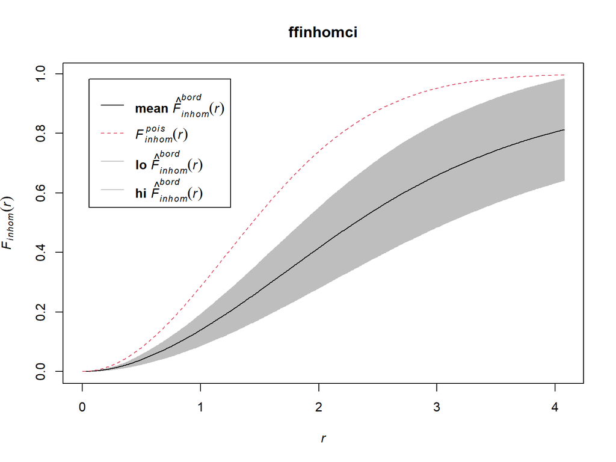

```r
ffinhomci <- varblock(dsub, fun = Finhom, correction = "none")
plot(ffinhomci)
```

# $G$-function: nearest-neighbour distance function

An empirical estimate of the probability that the nearest-neighbour distance is at most $r_0$:
$$\hat{G}(r_0) = \frac{\#(r_i-r_0)}{n}.$$
If the estimate is larger than CSR ($G(r) = 1- e^{-\pi \lambda r^2}$) then the points are clustered, if smaller than CSR then the points are regular.

$1-G(r)$ is the probability that a disk with radius $r$ centered at a randomly selected point does not contain a further point.

# $G$-function: nearest-neighbour distance function

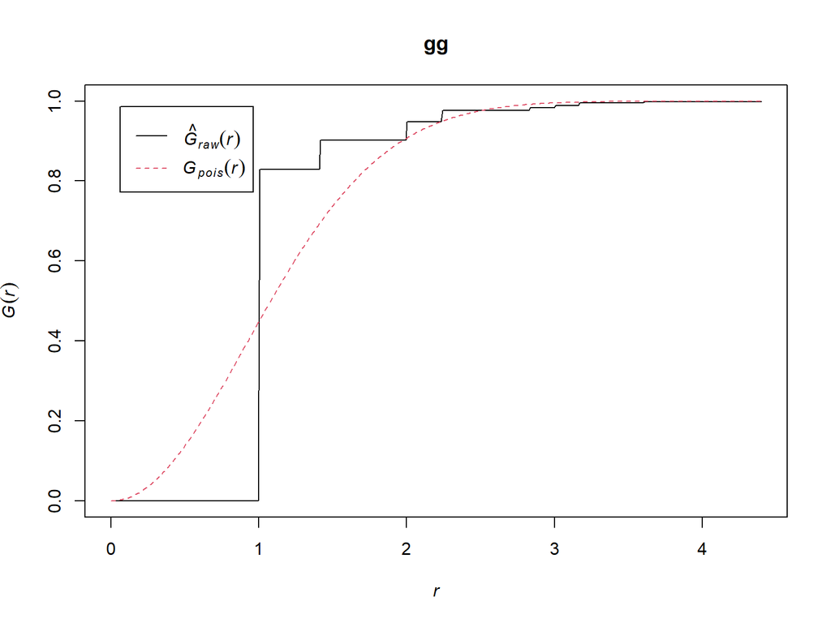

```r
gg <- Gest(dsub, correction = "none")
plot(gg)
```

# $G$-function: nearest-neighbour distance function

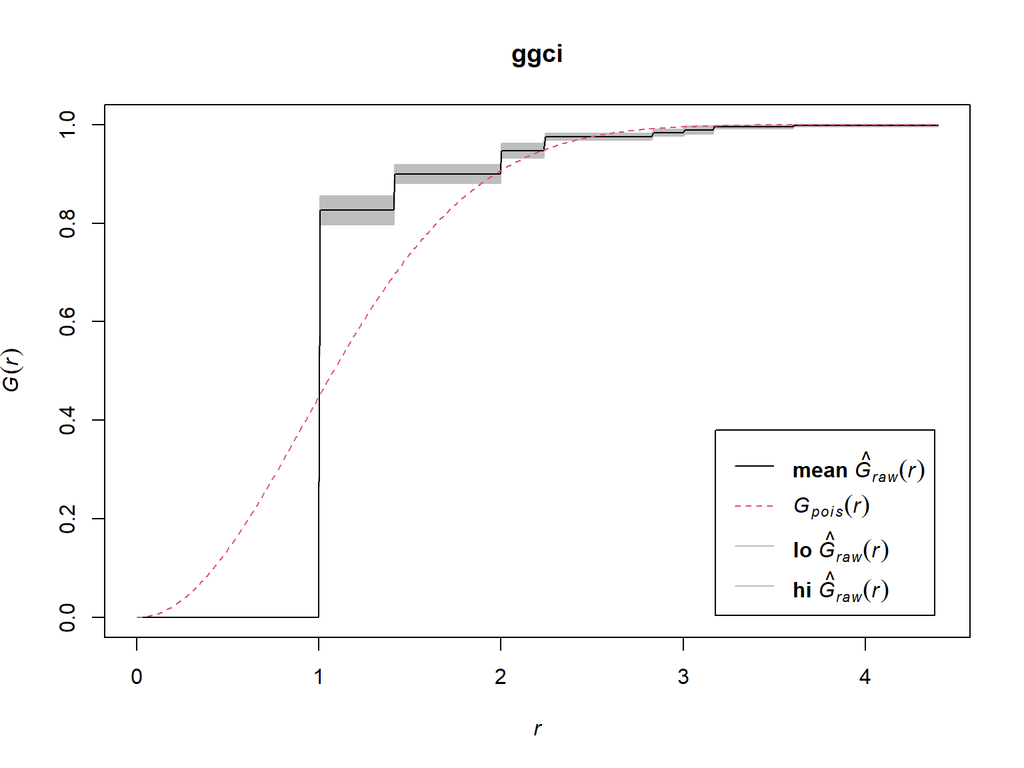

```r
ggci <- varblock(dsub, fun = Gest, correction = "none")
plot(ggci)
```

# $G$-function: nearest-neighbour distance function

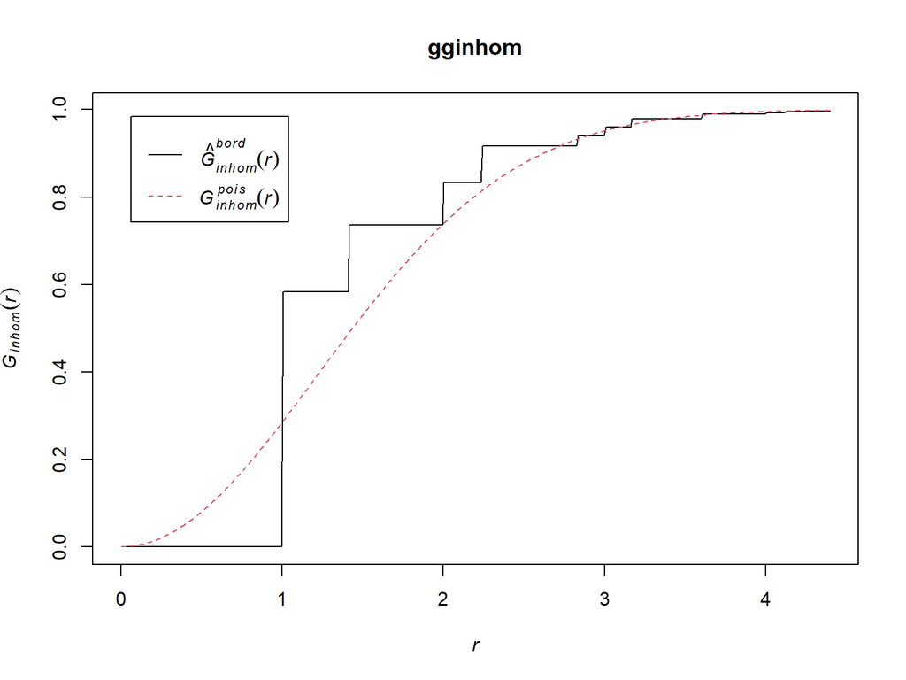

```r
gginhom <- Ginhom(dsub)
plot(gginhom)
```

# $G$-function: nearest-neighbour distance function

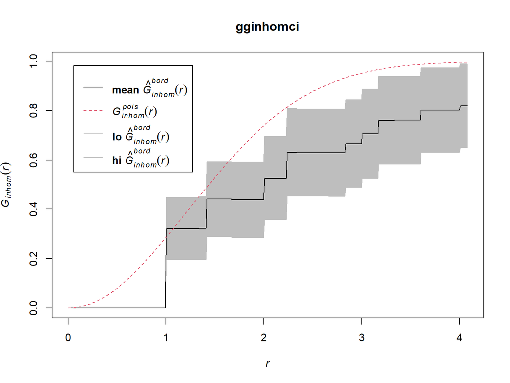

```r
gginhomci <- varblock(dsub, fun = Ginhom, correction = "none")
plot(gginhomci)
```